# Fitting logistic growth - OBS model

Author

Benjamin Rosenbaum

## Model

The logistic growth model can be written in the $r,\alpha$ or the $r,K$ formulation, where $K=\frac{r}{\alpha}$, or $\alpha=\frac{r}{K}$:

$$\begin{aligned}
\frac{dN}{dt} &= (r-\alpha N)N \\ &=r(1-\frac{N}{K})N
\end{aligned}$$

Using the trajectory fitting method (observation error only), we will fit all $m$ time series replicates with a joint set of parameters $r$ and $K$ (“complete pooling”), while allowing for $m$ individual initial states $N_0=N(t_0)$ as free parameters.

## Data preparation

The dataset `data_example_logistic.csv` contains `m=6` timeseries with `n=18` observations of densities [ind] each, including their dates [h]. The fraction of the observed volume for sampling was `f=0.1`.

```r
rm(list=ls())
library("rstan")
```

```r
data.in = read.csv("data_example_logistic.csv", row.names=1)

head(data.in)
```

```
     X1 X2  X3  X4  X5  X6  X7   X8   X9  X10  X11  X12  X13  X14  X15  X16
time  0 12  24  36  48  60  72   96  120  144  168  192  216  240  264  288
N1   10 36 106 270 562 914 994  968  904 1032 1010 1004  968 1010 1048  950
N2   24 30 136 262 532 846 942 1024 1024 1010 1016 1002 1082 1056  958 1088
N3   10 20 146 336 660 896 938  946 1016 1044  966  994 1004 1008 1086  932
N4   12 44 120 274 572 768 916 1010 1058 1066  992 1006  940  910 1016  998
N5   10 20  62 142 484 656 922  934 1000 1052  988 1004 1036 1056 1020  932
      X17  X18
time  312  336
N1    952 1072
N2   1078  954
N3   1006 1034
N4    916  972
N5   1062  976
```

For Stan, the data has to be coded as a named list, including dimensions of the data `n` and `m`, `times` as a vector, the `m` x `n` matrix `N` containing the observed abundances, and the sampling fraction `f`.

```r
n = ncol(data.in)
m = nrow(data.in)-1

times = as.numeric(data.in[1, ])
N = unname(as.matrix(data.in[2:(m+1), ]))

data = list(n = n,
            m = m,
            t = times,
            N = N,
            f = 0.1)

str(data)
```

```
List of 5
 $ n: int 18
 $ m: num 6
 $ t: num [1:18] 0 12 24 36 48 60 72 96 120 144 ...
 $ N: int [1:6, 1:18] 10 24 10 12 10 10 36 30 20 44 ...
 $ f: num 0.1
```

## Stan model

The Stan model is coded as a string, which is compiled later. A step by step walkthrough is given below.

```r
stanmodelcode = "
functions{
  vector odemodel(real t, vector N, vector p){
    // p[1]=r, p[2]=K
    vector[1] dNdt;
    dNdt[1] = p[1]*(1-(N[1]/p[2]))*N[1];
    return dNdt;
  }
}

data{
  int n; // observations
  int m; // replicates
  array[n] real t;
  array[m,n] int N;
  real f;
}

parameters{
  real<lower=0> r;
  real<lower=0> K;
  real<lower=0> tau;
  vector<lower=0>[m] N0sim; // individual initial values for replicates
}

model{
  vector[2] p;
  array[n-1] vector[1] Nsim; // simulated values, matrix. dim1 = time without t0, dim2 = dim_ODE = 1

  // priors
  r ~ lognormal(-2,1);
  K ~ lognormal(9,1);
  N0sim ~ normal(0,100);
  tau ~ gamma(2,0.1);

  // parameters for integrator
  p[1] = r;
  p[2] = K;

  for (j in 1:m){
    // integrate ODE
    Nsim = ode_rk45(odemodel, [N0sim[j]]', t[1], t[2:n], p);
    // likelihood
    N[j,1] ~ neg_binomial_2(N0sim[j]*f, tau);
    for (i in 2:n){
      N[j,i] ~ neg_binomial_2(Nsim[i-1,1]*f, tau);
    }
  }
}

generated quantities{
  real alpha = r/K;
}
"
```

### functions{ } block

The population growth equation (the ODE) is coded as a function. This function is later used for numerical integration. Although the logistic growth ODE has a closed-form analytical solution, we still use numerical solutions here, such that users can exchange the ODE for other models easily.

Stan requires a specific format: The output is a vector, and arguments time `t`, state `N`, and model parameters `p` are provided. The population growth rate `dNdt` is computed using the state `N` and parameters `p` (including `r` and `K`) and returned as the function’s output.

```
  vector odemodel(real t, vector N, vector p){
    // p[1]=r, p[2]=K
    vector[1] dNdt;
    dNdt[1] = p[1]*(1-(N[1]/p[2]))*N[1];
    return dNdt;
  }
```

### data{ } block

All data have to be declared including data types and dimensions. Names have to be identical to the named list which was defined in R before.

```
  int n; // observations
  int m; // replicates
  array[n] real t;
  array[m,n] int N;
  real f;
```

### parameters{ } block

Here, all free parameters are declared. This includes model parameters `r` and `K`, and a parameter `tau` for the residual distribution (overdispersion of the negative binomial). Additionally, the initial states of each of the `m` modelled time series `N0sim` in the total volume are estimated, too (defined as a vector). Its true states are unknown and observations are assumed to be measured with error. All parameters are required to be positive.

```
  real<lower=0> r;
  real<lower=0> K;
  real<lower=0> tau;
  vector<lower=0>[m] N0sim; // individual initial values for replicates
```

### model{ } block

This block defines how the posterior computed, using prior distributions and the likelihood function. First, some intermediate variables for the ODE simulation are declared. `p` is a vector which stores model parameters `r` and `K`. `Nsim` will contain the output of the numerical integration as an array of dimension `n-1` (at all timepoints minus the first one), each containing a vector of length 1 (number of states). This array-vector combination is required with the ODE solver function.

[output not shown]

Then, priors are defined for the model parameters. Weakly informative priors are chosen for both model parameters `r` and `K`. The overdispersion parameter `tau` of the residuals is constrained >0, but arbitrary small values are possible. We choose a gamma prior that decreases towards zero, such that sampling at low values near the boundary doesn’t cause convergence issues. The parameters for the initial values `N0sim` in the total volume are assigned weak priors, too.

```
  r ~ lognormal(-2,1);
  K ~ lognormal(9,1);
  N0sim ~ normal(0,100);
  tau ~ gamma(2,0.1);
```

After the priors are defined, predictions are computed. This includes numerically integrating the ODE, which requires all model parameters are stored in one vector `p`.

```
  p[1] = r;
  p[2] = K;
```

In a loop over all `m` time series replicates, numerical integration is performed. Each time series `j` gets its individual initial state `N0sim[j]`. The integration routine `ode_rk45()` is must be called in a specific format. Arguments are the function `odemodel` as defined in the `functions{}` block, the initial state is converted to an vector using `[ ]'`, then initial time `t[1]` and output times `t[2:n]`, and model parameters `p`.

After computing the predicted time series `Nsim`, it is confronted with the data `N`: a negative binomial distribution defines likelihood values. Since the data was sampled in a fraction `f=0.1`, the distribution’s mean is `Nsim[,]*f`, with some overdispersion `tau`.

Since predictions by `ode_rk45()` can only be generated for $t>t_1$, data `N[j,1]` and `N[j,i]` ($i>1$) have to be treated separately. The first observation `N[j,1]` is distributed around the prediction in $t_1$, which is equal to the free parameter `N0sim[j]*f` (estimated initial state). The remaining observations `N[j,i]` ($i>1$) are distributed around the predictions in $t_i$, respectively, which are equal to the output `Nsim[i-1,1]*f`. It is `i-1` instead of `i` here, because the output `Nsim` starts in $t_2$ and not in $t_1$.

```
  for (j in 1:m){
    // integrate ODE
    Nsim = ode_rk45(odemodel, [N0sim[j]]', t[1], t[2:n], p);
    // likelihood
    N[j,1] ~ neg_binomial_2(N0sim[j]*f, tau);
    for (i in 2:n){
      N[j,i] ~ neg_binomial_2(Nsim[i-1,1]*f, tau);
    }
  }
```

### generated quantities{ } block

Optionally, other quantities can be defined in this block. Samples of their posterior distributions are saved, too. E.g., we can save the term $\alpha=\frac{r}{K}$’ of the logistic growth model’s $r$,$\alpha$-formulation.

```
  real alpha = r/K;
```

## Model fitting

After defining the model code, we specify some parameters for the MCMC model fitting. Usually, 3–5 MCMC chains are used. These can be run in parallel on multicore processors, when options are specified accordingly. Further, we set the total number of iterations and number of warmup iterations for the sampling. The total number of posterior MCMC samples is `chains*(iter-warmup)`.

```r
# stan options
chains = 3
rstan_options(auto_write = TRUE)
options(mc.cores = chains)
iter   =  4000
warmup =  2000
```

Then starting values for all free parameters are provided as a list (in case of multiple chains: a list of lists). For the time series intial states `N0sim`, data in `t[1]` scaled up from the sampled fraction `f` to the total volume are a natural choice. Remaining parameters are given guesses. Stan usually converges quickly towards the parameter region featuring a high probability density. But with ODEs involved, good initial guesses that do not cause numerical issues in ODE integration are often required.

```r
# initial values for sampling
init=rep(list(list(r=0.1,
                   K=1e4,
                   N0sim=data$N[, 1]/data$f,
                   tau=10))
         ,chains)
```

Finally, the model is compiled and sampling is started.

```r
stanmodel = stan_model(model_code=stanmodelcode)

fit = sampling(stanmodel,
               data=data,
               iter=iter,
               warmup=warmup,
               chains=chains,
               init=init
)
```

## Model diagnostics

Convergence of the MCMC chains is checked, e.g. by looking at estimated model parameters. We check the effective sample size `n_eff` and the Gelman-Rubin diagnostics `Rhat` (should be <1.01), indicating that chains have mixed.

```r
print(fit, digits=3, pars=c("r","K","tau"), probs=c(0.025, 0.5, 0.975))
```

```
Inference for Stan model: anon_model.
3 chains, each with iter=4000; warmup=2000; thin=1;
post-warmup draws per chain=2000, total post-warmup draws=6000.

         mean se_mean     sd     2.5%       50%     97.5% n_eff Rhat
r       0.098   0.000  0.002    0.094     0.098     0.102  1880    1
K   10040.931   1.352 96.660 9851.394 10039.891 10235.956  5114    1
tau   178.210   0.443 30.771  124.152   176.142   244.419  4816    1

Samples were drawn using NUTS(diag_e) at Thu Jan 25 16:43:53 2024.
For each parameter, n_eff is a crude measure of effective sample size,
and Rhat is the potential scale reduction factor on split chains (at
convergence, Rhat=1).
```

Additionally, chains are inspected visually via trace- and density plots.

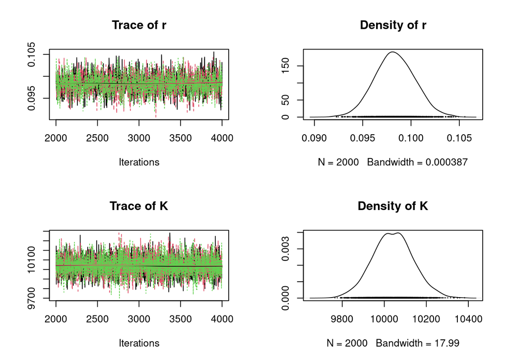

```r
library("coda")
samples=As.mcmc.list(fit)
plot(samples[, c("r","K")])
```

A pairs plot can detect correlations in model parameters. Almost perfect correlation would indicate non-identifiability.

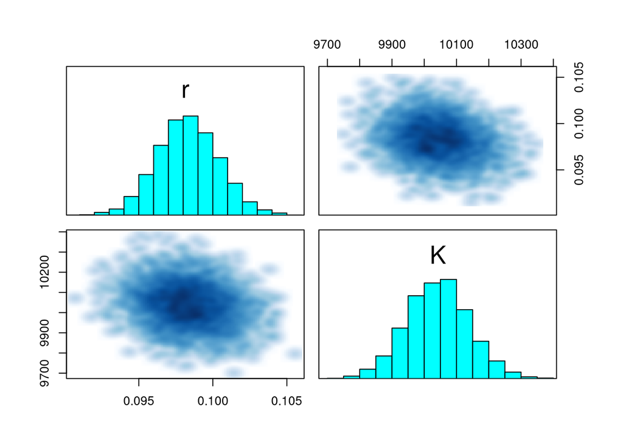

```r
pairs(fit, pars=c("r","K"))
```

Optional: We also computed posterior samples for $\alpha=\frac{r}{K}$ in the `generated quantities{}` block.

```r
print(fit, digits=7, pars=c("alpha"), probs=c(0.025, 0.5, 0.975))
```

```
Inference for Stan model: anon_model.
3 chains, each with iter=4000; warmup=2000; thin=1;
post-warmup draws per chain=2000, total post-warmup draws=6000.

         mean se_mean    sd    2.5%     50%    97.5% n_eff    Rhat
alpha 9.8e-06       0 2e-07 9.3e-06 9.8e-06 1.03e-05  2080 1.00042

Samples were drawn using NUTS(diag_e) at Thu Jan 25 16:43:53 2024.
For each parameter, n_eff is a crude measure of effective sample size,
and Rhat is the potential scale reduction factor on split chains (at
convergence, Rhat=1).
```

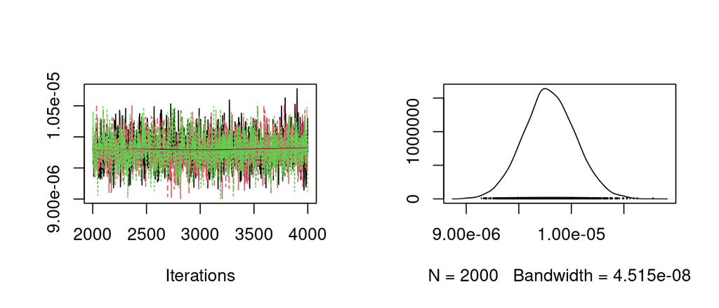

```r
plot(samples[, "alpha"])
```

## Posterior predictions

Posterior predictions can generated from sampled posterior parameters. Alternatively, this can be done while sampling using `generated quantities{}` block in the model code. Here, we use the `deSolve` package for numerical integration to compute posterior predictions. First, we code an R function defining the population growth rate (ODE).

```r
library("deSolve")

ode.model = function(t,N,p){
  dNdt =  p[1]*N[1]*(1.0-N[1]/p[2])
  return(list(dNdt))
}
```

Samples of the posterior distribution are converted to matrix. Each column contains all samples of a single parameter, while each row contains one sample from the multivariate posterior distribution.

```r
post = as.matrix(fit)
head(post)
```

```
          parameters
iterations          r         K      tau N0sim[1] N0sim[2] N0sim[3] N0sim[4]
      [1,] 0.09830902 10060.662 173.8696 115.1136 126.7586 143.7389 111.3578
      [2,] 0.09862060 10005.831 163.3679 111.5848 112.7849 140.0296 137.5194
      [3,] 0.10093434 10245.483 243.4319 110.2174 106.3833 125.7680 106.8168
      [4,] 0.09774214  9846.122 139.2633 110.9538 121.4678 125.5435 122.0452
      [5,] 0.09675628 10107.997 190.8351 108.7254 119.3558 139.9198 114.0418
      [6,] 0.09699104 10029.037 179.3652 114.6437 125.9030 139.4805 123.9393
          parameters
iterations N0sim[5] N0sim[6]        alpha      lp__
      [1,] 62.46861 86.00926 9.771625e-06 -542.9887
      [2,] 62.62043 83.06217 9.856313e-06 -544.6612
      [3,] 60.15286 78.91982 9.851594e-06 -548.9962
      [4,] 61.83777 82.46311 9.926968e-06 -545.9667
      [5,] 61.62513 82.60528 9.572250e-06 -544.2912
      [6,] 62.24838 84.81425 9.671022e-06 -542.1170
```

`t.pred` includes times for which predictions are generated. The empty matrix `N.pred` will store all predicted values: each row will contain one sample of a predicted timeseries.

```r
n.post = 1000 # nrow(post)
t.pred = seq(from=min(data$t), to=max(data$t), by=1)
N.pred = matrix(NA, nrow=n.post, ncol=length(t.pred))
```

Predictions are generated for each time series replicate seperately (for-loop over `i`). For each sample from the posterior (row `j` in matrix `post[j, ]`), the trajectory is computed by numerically integrating the ODE with parameters `r` and `K`, starting in initial state `N0sim[i]`. Each column `k` of `N.pred[ ,k]` contains posterior predictions in `t.pred[k]`. We calculate quantiles of these predictions and plot them against the data, which are scaled up to the total volume by dividing by the sampling fraction: `data$N[,]/data$f`.

Note that predicted time series differ only in their initial states `N0sim[i]`, since model parameters `r` and `K` are identical across time series replicates $i$.

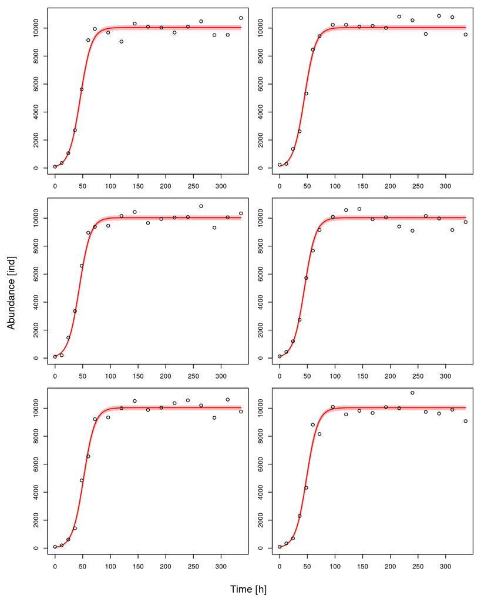

```r
par(mfrow=c(3,2), mar=c(3,3,0,0), oma=c(3,3,1,1))
for(i in 1:m){
  for(j in 1:n.post){
    N.pred[j, ] = as.data.frame(lsoda(y     = c( N = post[j, paste0("N0sim[",i,"]")] ),
                                      times = t.pred,
                                      func  = ode.model,
                                      parms = c(post[j, "r"],
                                                post[j, "K"])
    ))$N
  }

  N.pred.qs = apply(N.pred, 2, function(x) quantile(x, probs=c(0.025,0.500,0.975), na.rm=TRUE))

  plot(data$t, data$N[i, ]/data$f,
              ylim=c(0,1.1e4), type="n", xlab="", ylab="")
  polygon(c(t.pred, rev(t.pred)), c(N.pred.qs[1, ], rev(N.pred.qs[3, ])),
          col = adjustcolor("red",alpha.f=0.25),  border = NA)
  lines(t.pred, N.pred.qs[2, ], col="red", lwd=1.5)
  points(data$t, data$N[i, ]/data$f)
}
mtext("Time [h]", side=1, outer=TRUE, line=1)
mtext("Abundance [ind]", side=2, outer=TRUE, line=1)
```